# EDA for Wine Quality Dataset

Ammar Alfaifi

2022-06-16

# Introduction

This a report about the wine quality dataset downloaded form kaggle api. In this report we will examine this dataset and explore it to find out its significant as well as the research questions that might answer. This approach is commonly called Exploratory Data Analysis (in short, EDA).

# Data

As described form the kaggle sourse in [source](https://www.kaggle.com/datasets/uciml/red-wine-quality-cortez-et-al-2009), this datasets is related to red variants of the Portuguese “Vinho Verde” wine.

## Describing the headers

[output not shown]

# EDA

Loading and cleaning the header names

```r
read_csv(here("data/winequality-red.csv")) %>%
    clean_names() -> wine_data
glimpse(wine_data)
```

```
## Rows: 1,599
## Columns: 12
## $ fixed_acidity        <dbl> 7.4, 7.8, 7.8, 11.2, 7.4, 7.4, 7.9, 7.3, 7.8, 7.5…
## $ volatile_acidity     <dbl> 0.700, 0.880, 0.760, 0.280, 0.700, 0.660, 0.600, …
## $ citric_acid          <dbl> 0.00, 0.00, 0.04, 0.56, 0.00, 0.00, 0.06, 0.00, 0…
## $ residual_sugar       <dbl> 1.9, 2.6, 2.3, 1.9, 1.9, 1.8, 1.6, 1.2, 2.0, 6.1,…
## $ chlorides            <dbl> 0.076, 0.098, 0.092, 0.075, 0.076, 0.075, 0.069, …
## $ free_sulfur_dioxide  <dbl> 11, 25, 15, 17, 11, 13, 15, 15, 9, 17, 15, 17, 16…
## $ total_sulfur_dioxide <dbl> 34, 67, 54, 60, 34, 40, 59, 21, 18, 102, 65, 102,…
## $ density              <dbl> 0.9978, 0.9968, 0.9970, 0.9980, 0.9978, 0.9978, 0…
## $ p_h                  <dbl> 3.51, 3.20, 3.26, 3.16, 3.51, 3.51, 3.30, 3.39, 3…
## $ sulphates            <dbl> 0.56, 0.68, 0.65, 0.58, 0.56, 0.56, 0.46, 0.47, 0…
## $ alcohol              <dbl> 9.4, 9.8, 9.8, 9.8, 9.4, 9.4, 9.4, 10.0, 9.5, 10.…
## $ quality              <dbl> 5, 5, 5, 6, 5, 5, 5, 7, 7, 5, 5, 5, 5, 5, 5, 5, 7…
```

```r
status(wine_data)
```

```
##                                  variable q_zeros    p_zeros q_na p_na q_inf
## fixed_acidity               fixed_acidity       0 0.00000000    0    0     0
## volatile_acidity         volatile_acidity       0 0.00000000    0    0     0
## citric_acid                   citric_acid     132 0.08255159    0    0     0
## residual_sugar             residual_sugar       0 0.00000000    0    0     0
## chlorides                       chlorides       0 0.00000000    0    0     0
## free_sulfur_dioxide   free_sulfur_dioxide       0 0.00000000    0    0     0
## total_sulfur_dioxide total_sulfur_dioxide       0 0.00000000    0    0     0
## density                           density       0 0.00000000    0    0     0
## p_h                                   p_h       0 0.00000000    0    0     0
## sulphates                       sulphates       0 0.00000000    0    0     0
## alcohol                           alcohol       0 0.00000000    0    0     0
## quality                           quality       0 0.00000000    0    0     0
##                      p_inf    type unique
## fixed_acidity            0 numeric     96
## volatile_acidity         0 numeric    143
## citric_acid              0 numeric     80
## residual_sugar           0 numeric     91
## chlorides                0 numeric    153
## free_sulfur_dioxide      0 numeric     60
## total_sulfur_dioxide     0 numeric    144
## density                  0 numeric    436
## p_h                      0 numeric     89
## sulphates                0 numeric     96
## alcohol                  0 numeric     65
## quality                  0 numeric      6
```

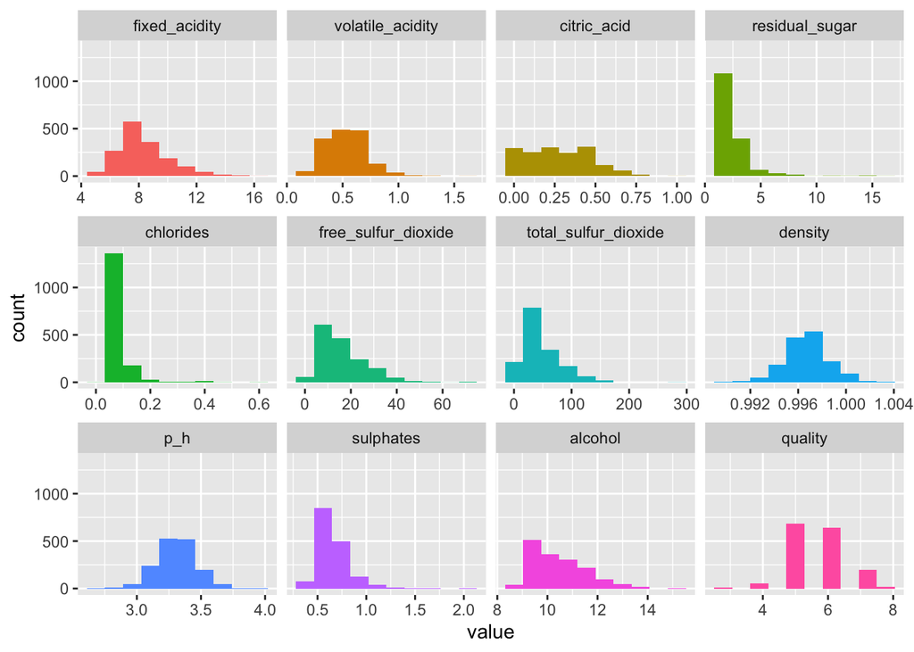

```r
plot_num(wine_data)
```

The above graphs show the count of observations for each catogerical along with their values. We can note that for `chlorides` thre is string positve skweness. This might indicat unnormal value. Further for `total_sulfur_dioxide`, it has relatively large sdandard deviation. This can be due to imprecise measuring. Let us investigate more about the later.

```r
profiling_num(wine_data$total_sulfur_dioxide)
```

```
##   variable     mean  std_dev variation_coef p_01 p_05 p_25 p_50 p_75  p_95 p_99
## 1      var 46.46779 32.89532      0.7079167    8   11   22   38   62 112.1  145
##   skewness kurtosis iqr range_98   range_80
## 1 1.514109 6.794172  40 [8, 145] [14, 93.2]
```

The variation_coef is about 0.7, wich indicate hight uncertinity about whether the total_sulfur_dioxide has that effect on the wine quality. It us inresting question to analize more about this connection.

## Show Some Catogericals

```r
wine_data %>%
    select(chlorides, alcohol, quality) -> selected_table
datatable(selected_table)
```

|  | chlorides | alcohol | quality |
| --- | --- | --- | --- |
| 1 | 0.076 | 9.4 | 5 |
| 2 | 0.098 | 9.8 | 5 |
| 3 | 0.092 | 9.8 | 5 |
| 4 | 0.075 | 9.8 | 6 |
| 5 | 0.076 | 9.4 | 5 |
| 6 | 0.075 | 9.4 | 5 |
| 7 | 0.069 | 9.4 | 5 |
| 8 | 0.065 | 10 | 7 |
| 9 | 0.073 | 9.5 | 7 |
| 10 | 0.071 | 10.5 | 5 |

[output cut: 1589 more lines]

# Conclusion

to sum up, this dataset has many catogericals that are intresting to analize and study.Furthermore, it can leads to a good understanding of how different compoents can increase the wine quality. More analysis hypothsis testing is needed to determine best practice for wine manufacturers to produce high wine quality with balance.